### 4월/1주

#### ▶ ▣ 정당지지도 ▣

더불어민주당 35.2%, 국민의힘 35.7%, 녹색정의당 1.9%, 새로운미래 2.6%, 개혁신당 3.1%, 조국혁신당 11.3%, 그 외 다른 정당 2.3%, 지지하는 정당 없다 6.7%, 잘 모르겠다 1.1%

#### ▶ ▣ 대통령 국정 수행 평가 ▣

잘하고 있다 37.6%, 잘못하고 있다 60.1%, 잘 모르겠다 2.3%

#### ☑ ▣ 총선 투표 의향 ▣

사전 투표일에 투표할 것이다 44.7%, 본 투표일에 투표할 것이다 51.8%, 투표 여부를 아직 결정 못했다 2.4%, 투표하지 않을 것이다 1.2%

#### ☑ ▣ 총선 1당 유력 정당 전망 ▣

더불어민주당 50.1%, 국민의힘 36.3%, 녹색정의당 1.2%, 새로운미래 2.3%, 개혁신당 1.7%, 조국혁신당 4.3%, 그 외 다른 정당 0.5%, 잘 모르겠다 3.5%

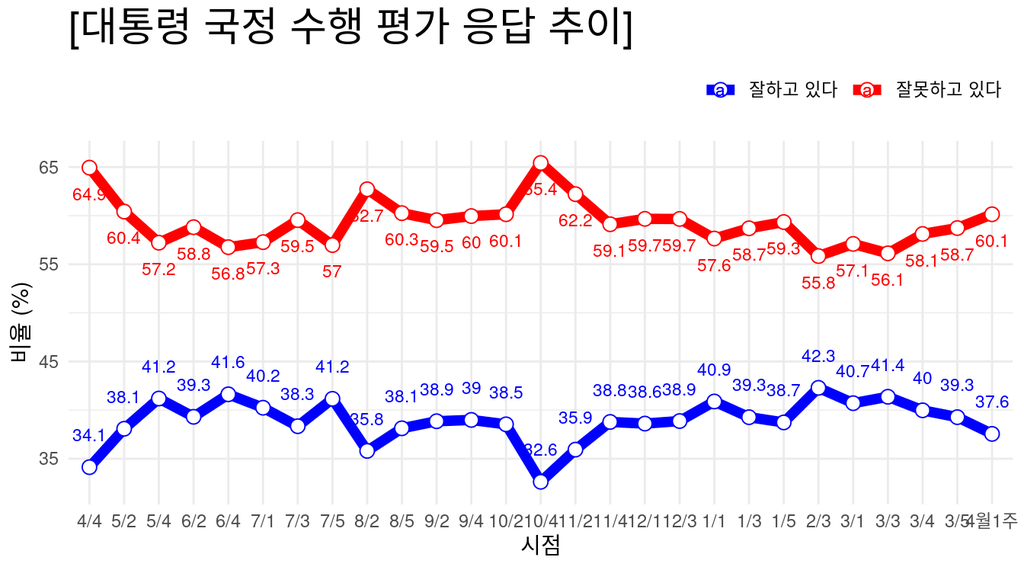

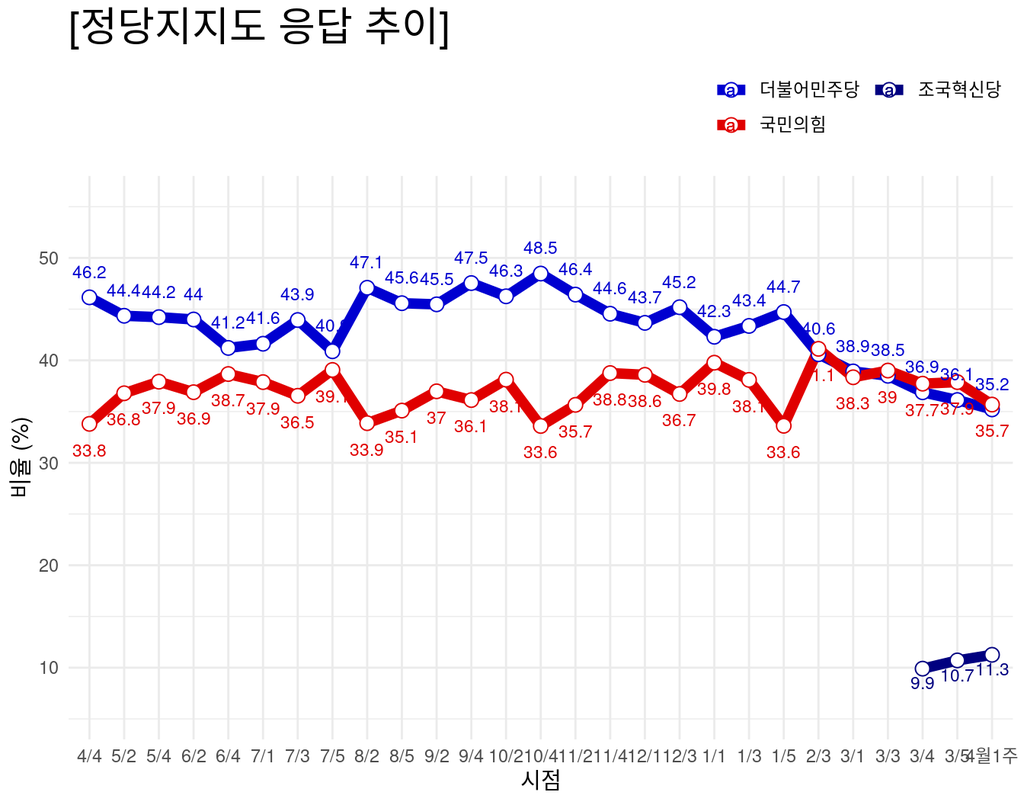

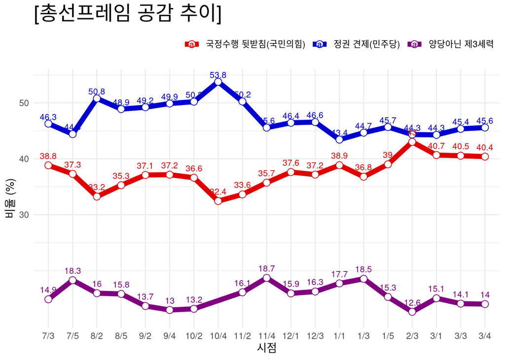

### 추가사항

- [주요질문 / 집단별 세부통계 보기](https://modernity.shinyapps.io/survey_str/) (링크누르시오)

### 참고사항

- 표본수: 2,033명,표본오차는 95% ±2.2%p
- 조사정보: 스트레이트뉴스의 의뢰로 조원씨앤아이가 2024년 3월 30일~4월 1일 3일간

  전국 만 18세 이상 남녀를 대상으로 ARS 여론조사

  (휴대전화 100% RDD 방식, 성,연령대,지역별 비례할당 후 무작위 추출)를 실시한 결과이며,

  표본수는 2,033(총 통화시도 47,820명, 응답률 4.3%)

  ※ 가중치 부여 방식: [림가중] 성별, 연령별, 지역별 가중값 부여(2024년 3월말 행정안전부 발표 주민등록인구기준)
- [중앙선거여론조사심의위원회](https://nesdc.go.kr/portal/bbs/B0000005/list.do?menuNo=200467)에서 관련사항 확인가능

2024.04.03 (Wed) 19:31 제작

- 연구개발 단계입니다.
- 제공: 감동과 마음의 [조원씨앤아이](http://jowoncni.com/html/index.html)